# Aplicação de ferramentas estatísticas em dados jurídicos

Matheus Souto

# Eficiência x Justiça

Juízes analisam milhares de casos durante anos de trabalho, sendo possível que a decisão seja contestada ou não. A classificação de juízes em um critério de eficiência quanto aos casos julgados seria muito importante em um país como o Brasil, com elevada diversidade e Constituição extensa.

Os casos analisados podem ser monitorados e, a partir dos mesmos, salientar quais seriam mais ou menos eficientes, trazendo um indicativo simples e direto para a sociedade de custo-benefício. Além disso, juízes mais eficientes poderiam ser bonificados e os menos eficientes punidos.

Com o intuito de fazer essa classificação, os 38 juízes do Tribunal de Justiça Estadual (TJE) tiveram seus casos monitorados por um período de três anos, totalizando 182.908 casos julgados. Os casos faziam parte das esferas: cível, criminal e fazenda pública. Além disso, aqueles que foram apelados e/ou revertidos diante do veredito apresentado podem resultar de erros de juízes de instâncias iniciais.

A fim de identificar quais juízes estão tendo um bom desempenho em seu trabalho ou não, avaliou-se os dados fornecidos. A classificação dos juízes também é feita, fornecendo indicadores para o setor jurídico estadual.

Para que seja possível classificar os juízes de acordo com sua eficiência, foi elaborado um ranking que leva em consideração o número de casos julgados por cada juiz e a probabilidade de que um caso que foi julgado por determinado juiz seja apelado e, posteriormente, revertido. Uma vez que a reversão de um caso gera indícios de que houve algum erro de julgamento nas instâncias inferiores, a probabilidade de reversão dos casos de um juiz pode ser um bom indicador da eficiência do mesmo.

# Relação entre casos Apelados e Revertidos

Durante o processo de criação foram calculadas as probabilidades de um caso ser apelado e revertido para cada juiz. A probabilidade de um caso ser apelado em relação ao total de casos julgados é de 1,29%.

```r
sum(dados$Apelados)/sum(dados$Julgados)*100
```

```
## [1] 1.29464
```

Quando se trata dessa probabilidade para cada juiz, pode-se destacar J38 como o que possui menor probabilidade (0,002%) e J13, que possui a maior probabilidade de ter um caso apelado (0,079%). Dentro dos casos apelados, isso significa que 0,17% foi apelado pelo J38 e 6,12% pelo J13, respectivamente.

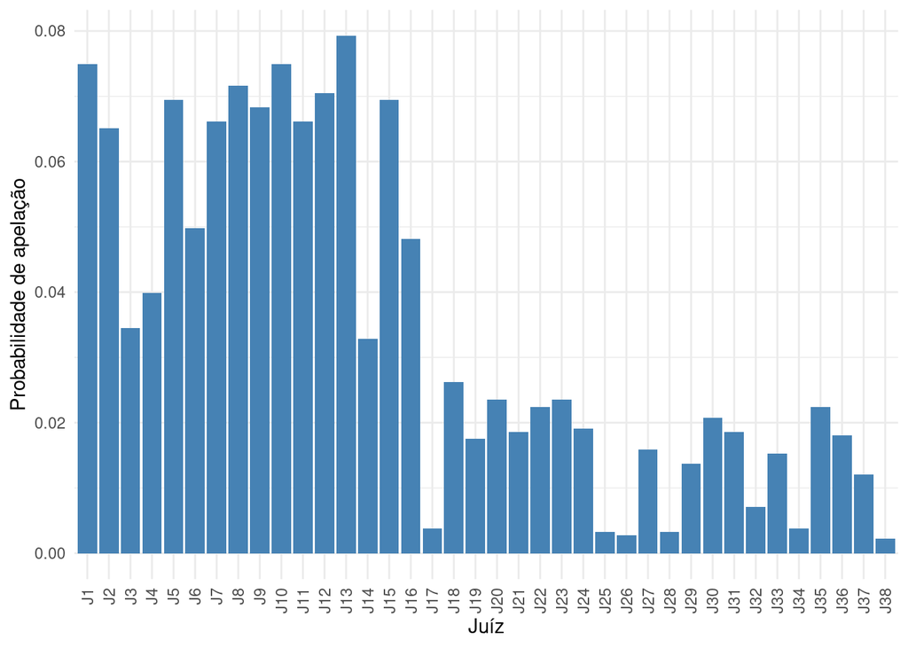

```r
dados$prob_apelacao <- dados$Apelados/sum(dados$Julgados)*100
dados$prob_reverter <- dados$Revertidos/sum(dados$Julgados)*100
p<-ggplot(data=dados, aes(y=prob_apelacao, x=reorder(Juiz,dados$indice))) +
  geom_bar(stat="identity", fill="steelblue")+
  labs(y='Probabilidade de apelação', x='Juíz')+
  theme_minimal()
p + theme(axis.text.x = element_text(angle = 90, vjust = 0.5, hjust=1))
```

Já para os casos revertidos, sua proporção em relação ao total de casos julgados foi de 0,17%.

```r
(sum(dados$Revertidos)/sum(dados$Julgados))*100
```

```
## [1] 0.1749513
```

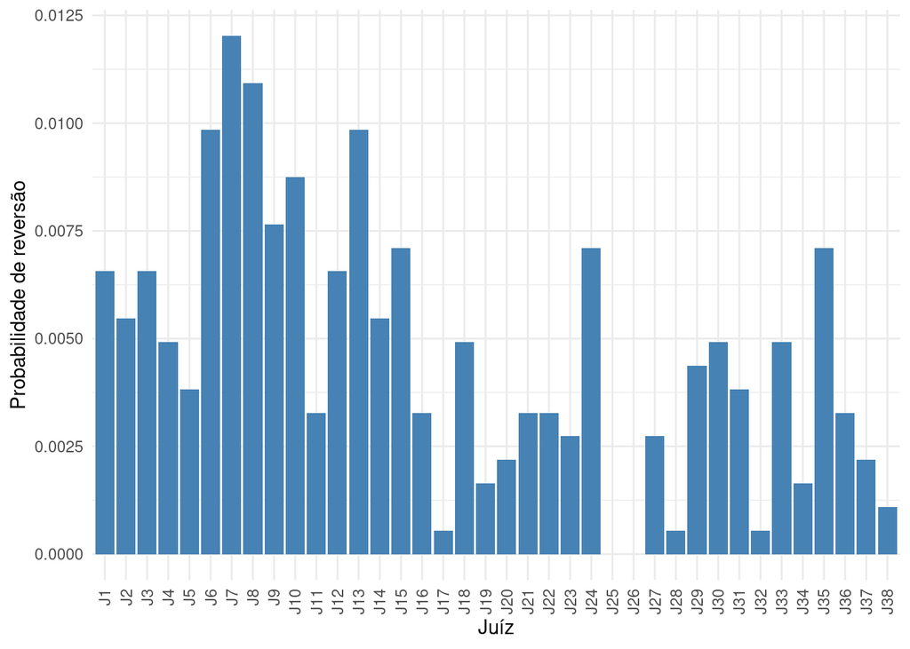

```r
q<-ggplot(data=dados, aes(y=prob_reverter, x=reorder(Juiz,dados$indice))) +
  geom_bar(stat="identity", fill="steelblue")+
  labs(y='Probabilidade de reversão', x='Juíz')+
  theme_minimal()
q + theme(axis.text.x = element_text(angle = 90, vjust = 0.5, hjust=1))
```

Dentre os casos apelados, 13,51% foram revertidos. Desse total, J7 é o que teve maior reversão considerando a condição de ter sido apelado e os juízes J25 e J26 apresentam menor grau de reversão. É importante salientar que essa estatística pode não ser a mais eficiente para ranquear os juízes pois ela traz uma relação da quantidade revertida pelo juiz em questão, em relação ao total de apelados.

```r
(sum(dados$Revertidos)/sum(dados$Apelados))*100
```

```
## [1] 13.51351
```

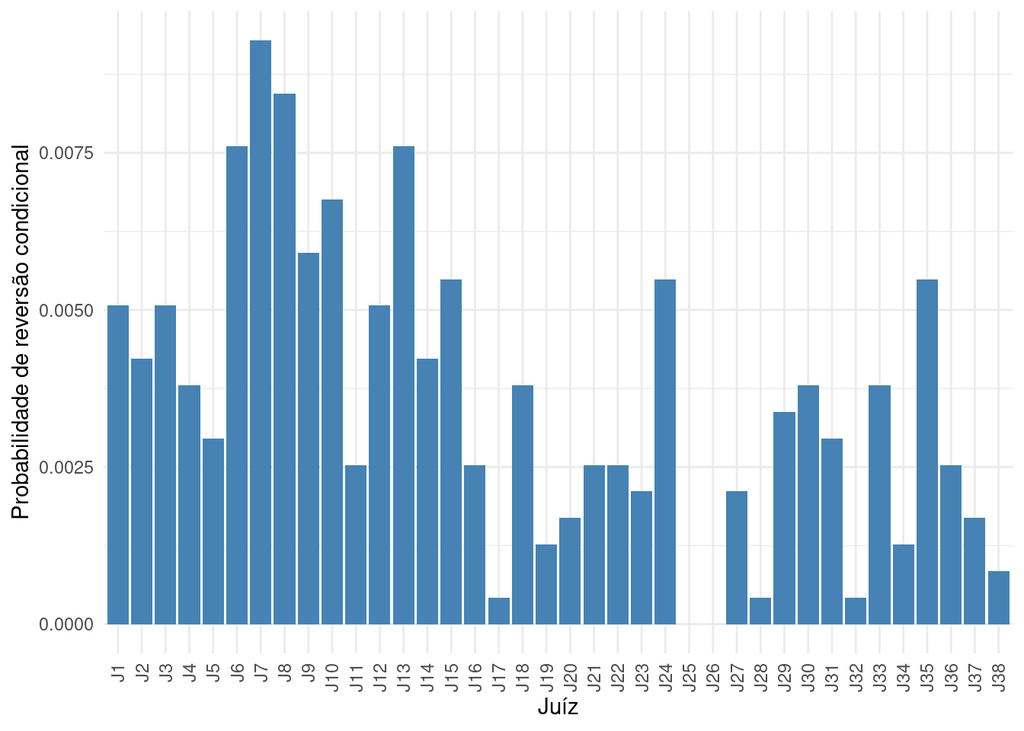

```r
dados$condicional<-dados$Revertidos/sum(dados$Apelados)
u<-ggplot(data=dados, aes(y=condicional, x=reorder(Juiz,dados$indice))) +
  geom_bar(stat="identity", fill="steelblue")+
  labs(y='Probabilidade de reversão condicional', x='Juíz')+
  theme_minimal()
u + theme(axis.text.x = element_text(angle = 90, vjust = 0.5, hjust=1))
```

#Índice de eficiência

O índice de eficiência dos juízes leva em consideração o número de casos de julgados e a probabilidade de reversão, dado que foi julgado pelo juíz em questão. Isso significa que o juiz mais eficiente será aquele que teve o maior número de casos julgados e o menor probabilidade de reversão. Para o cálculo desse índice, foi realizada uma padronização dos dados, isso significa que, quanto mais eficiente for um juíz mais próximo de 1 será o seu score. Enquanto o juiz que está mais próximo do 0 teve um número baixo de casos julgados e um número elevado de casos revertidos.

```r
dados$prob_reversao_condicional<-dados$Revertidos/dados$Julgados*100
for(i in 1:40){
  dados$prob_reversao_padronizada[i]<- (dados$prob_reversao_condicional[i] - min(dados$prob_reversao_condicional))/(max(dados$prob_reversao_condicional)-min(dados$prob_reversao_condicional))
  i<-i+1
}
for(i in 1:40){
  dados$julgados_padronizado[i]<- (dados$Julgados[i] - min(dados$Julgados))/(max(dados$Julgados)-min(dados$Julgados))
  i<-i+1
}
dados$score<-0
for(i in 1:40){
dados$score[i]<-((1-dados$prob_reversao_padronizada[i])*0.5)+(dados$julgados_padronizado[i]*0.5)
i<-i+1
}
library(dplyr)
library(knitr)
print(arrange(dados[,c(1,13)], desc(dados$score)), n = 40)
```

```
## # A tibble: 40 × 2
##    Juiz  score
##    <chr> <dbl>
##  1 J19   0.989
##  2 J18   0.778
##  3 J31   0.762
##  4 J27   0.759
##  5 J22   0.755
##  6 J30   0.753
##  7 J23   0.751
##  8 J21   0.749
##  9 J35   0.705
## 10 J20   0.685
## 11 J25   0.679
## 12 J3    0.678
```

[output cut: 28 more lines]